# Plot assignment

Template: Ian Hussey; content: Sarah Schnyder

11 Januar, 2024

# Dependencies

```r
library(tidyverse)
library(readr)
library(ggrain)
```

# Instructions

The goal of this exercise is to produce both good and bad examples of plots *and to be explicit about what makes them good or bad*.

The data can be real or fabricated. The plots can convey realistic or silly messages - but they must convey them clearly. You can get real data from many sources. A good one is the open science framekwork (osf.io). You can also simply make up data, either by hand or using simulation functions (e.g., `rnorm`) or the many simulation packages. If simulating data, ensure that you (a) use set.seed() to make it reproudbile, and (b) save a copy of the final data that you’re using to disk and then reload it in the script so that the plot is reproducible.

The goal is neither to reproduce the types of plots that you most often see in journals (bar plots, etc.) nor to use a very fancy looking plot just for the sake of it - if it is very unlikely that you’d ever be able to use the plot to convey a research finding in an article, blog, poster, tweet, infographic or otherwise, it’s probably not a good choice either.

The plots must be reproducible. Provide the data as well as the code to reproduce them. The plots should also be saved as individual images (pdf or png).

Under each plot, here in the RMarkdown, briefly explain what types of analysis the plot is suitable for, what elements of the results the plot attempts to clearly convey. For the bad plot, do the opposite: emphasise what features of the results the plot obscures or makes unclear. In doing so, communicate to me that you understand what makes a good plot to convey the results of quantiative analyses to viewers.

Consider making use of the many extensions to ggplot2, e.g.:

- https://r-graph-gallery.com
- https://krzjoa.github.io/awesome-r-dataviz/#/
- ggdist https://mjskay.github.io/ggdist/
- ggrepel
- ggpubr
- see
- ggsignif
- and others: https://exts.ggplot2.tidyverse.org/gallery/

# Simulating data

```r
# Set seed for reproducibility
set.seed(123)

# defining how many rows
n_rows <- 100

# generating random values for a few columns
gender <- sample(c("male", "female"), n_rows, replace = TRUE)
extraversion <- rnorm(n_rows, mean = 3, sd = 1) |>
  round(1) |>
  pmin(5) |>
  pmax(1)


# creating the data frame
sim_data <- data.frame(gender, extraversion)

# show the first few rows of the dataset
head(sim_data)
```

```
##   gender extraversion
## 1   male          3.3
## 2   male          3.0
## 3   male          3.0
## 4 female          4.4
## 5   male          2.8
## 6 female          4.5
```

```r
# save the dataset
dir.create("data")
write_csv(sim_data, "data/sim_data.csv")

# reloading the dataset
sim_data <- read.csv("data/sim_data.csv")
```

# Good plot

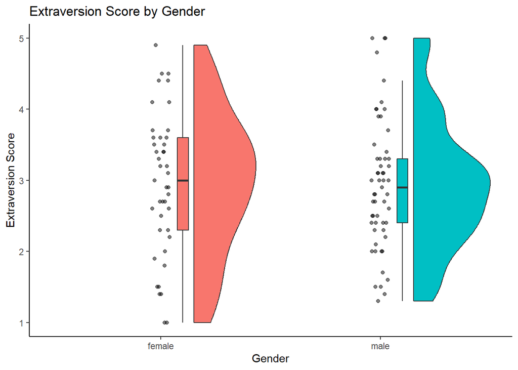

```r
p_good <- ggplot(sim_data, aes(x = gender, y = extraversion, fill = gender)) +
  geom_rain(
    point.args = list(alpha = 0.5)
  ) +
  labs(title = "Extraversion Score by Gender",
       x = "Gender",
       y = "Extraversion Score") +
  theme_classic()+
  scale_y_continuous(
    breaks = seq(1, 5, 1),
    limits = c(1,5)
  ) +
  theme(legend.position = "none")
p_good
```

The raincloud plot is suitable for comparing a continuous variable between groups, as in this case extraversion scores between genders. A raincloud plot combines the advantages of box plots, density plots and scatter plots. The box plot shows the median and the first and third quartile. The density plot shows the distribution of the data and the scatter plot the inidvidual data values. Even though it contains a lot, it is still quite easy to understand a raincloud plot.

# Bad plot

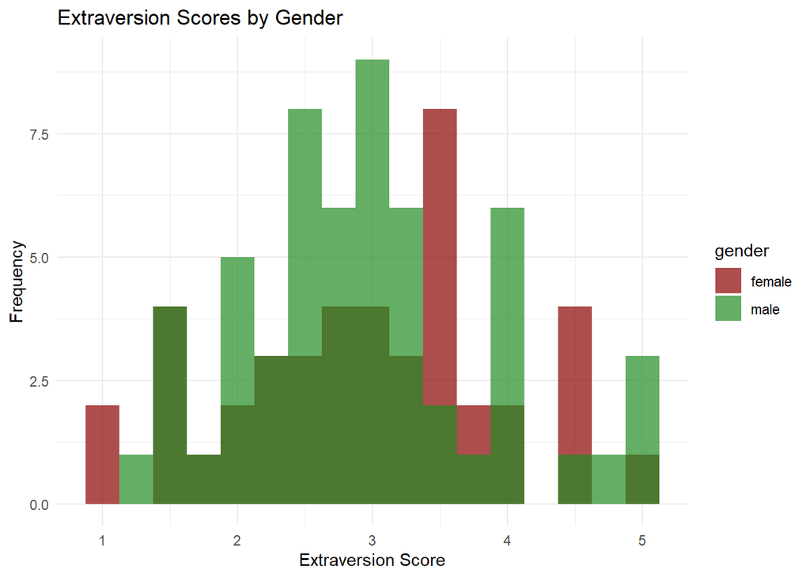

```r
p_bad <- ggplot(sim_data, aes(x = extraversion, fill = gender)) +
  geom_histogram(binwidth = 0.25, position = "identity", alpha = 0.7) +
  scale_fill_manual(values = c("darkred", "forestgreen")) +
  labs(title = "Extraversion Scores by Gender",
       x = "Extraversion Score", y = "Frequency") +
  theme_minimal()

p_bad
```

The histogram shows the distribution of the extraversion score for both genders. The data of the two groups overlap, which makes them comparable, but it can be hard to only look at one of the groups. Especially if the plot is going to be printed black and white it’s going to be really hard to distinct the two groups. The colors are not choosen wisely, because the most common type of color blindness is red-green deficiency.

A histogram does not display individual data points and only represents the overall pattern of the distribution. Because of that outliers or specific data points can not be seen. Especially if the number of bins or the binwidth is not chosen wisely, a lot of information can get lost.

It’s not suitable to compare different groups, because there is no measure of central tendency (e.g. mean or median) marked on the plot.

# Write to disk

Write to disk as a .pdf or .png.

Name them “plot_good_[yourname]” and “plot_bad_[yourname]”.

```r
dir.create("plots/")

ggsave("plots/plot_good_sarahschnyder.pdf", p_good, width = 8, height = 6)
ggsave("plots/plot_bad_sarahschnyder.pdf", p_bad, width = 8, height = 6)
```